# Cocacola Earnings - Optional Project - Forecasting Time Series

Group D - MBD O-1

22 february 2019

We split the data in order to in the end check for the accuracy of our prediction. Since we have time series data, it is very important to keep the last rows of the data as the test set, since this is the data we will try to predict with the model we will get from the previous quarterly observations.

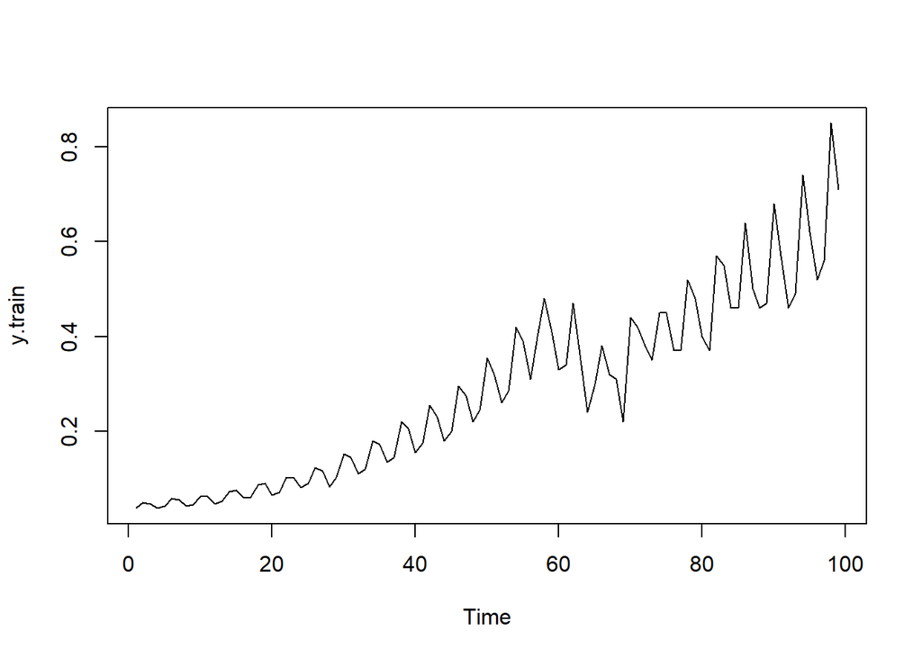

```r
#reading the data and taking the training set (the first 100 values)
data<-read.csv("coca_cola_earnings.csv",header=TRUE,sep=";",dec=",")
y.train <- data[1:99,2]

ts.plot(y.train)
```

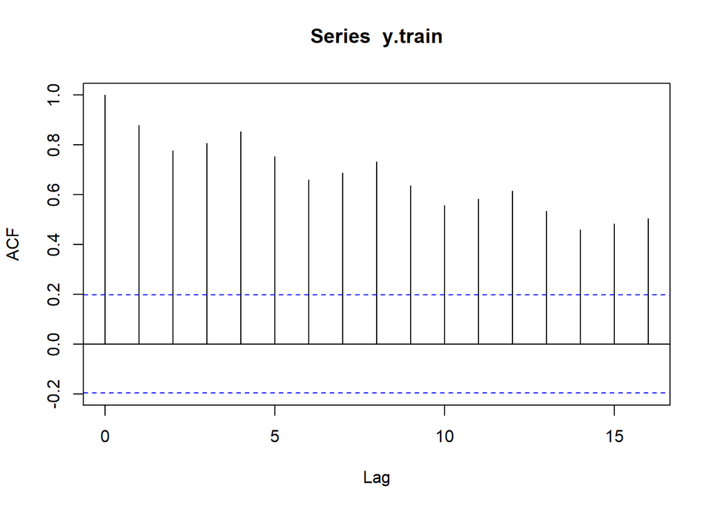

```r
nlags=16

acf(y.train,nlags)
```

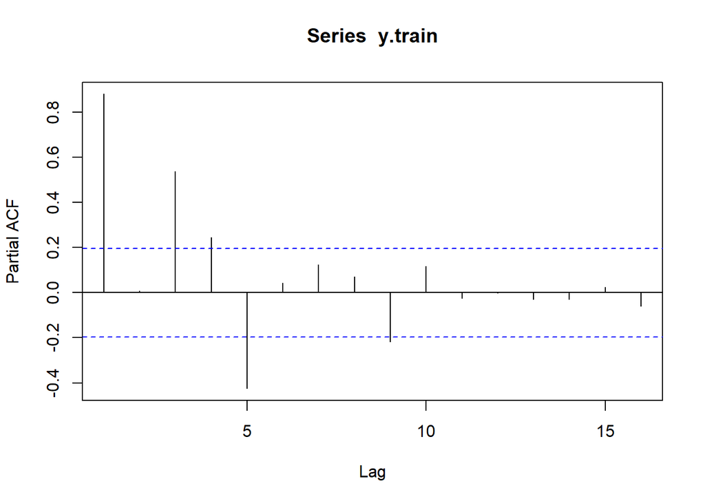

```r
pacf(y.train,nlags)
```

Applying the Dickey-Fuller test, we can see that one transformation is needed to make the data stationary for both the seasonal differences and the regular differences (the result is 1 in both cases). For this reason, our baseline model will be a SARIMA (0,1,0) x (0,1,0).

```r
s=4      # seasonal parameter
nsdiffs(y.train,m=s,test=c("ocsb"))  # seasonal differences?
```

```
## [1] 1
```

```r
ndiffs(y.train, alpha=0.05, test=c("adf")) # regular differences?
```

```
## [1] 1
```

```r
fit<-arima(y.train,order=c(0,1,0),seasonal=list(order=c(0,1,0),period=s))
fit
```

```
##
## Call:
## arima(x = y.train, order = c(0, 1, 0), seasonal = list(order = c(0, 1, 0), period = s))
##
##
## sigma^2 estimated as 0.001556:  log likelihood = 170.52,  aic = -339.04
```

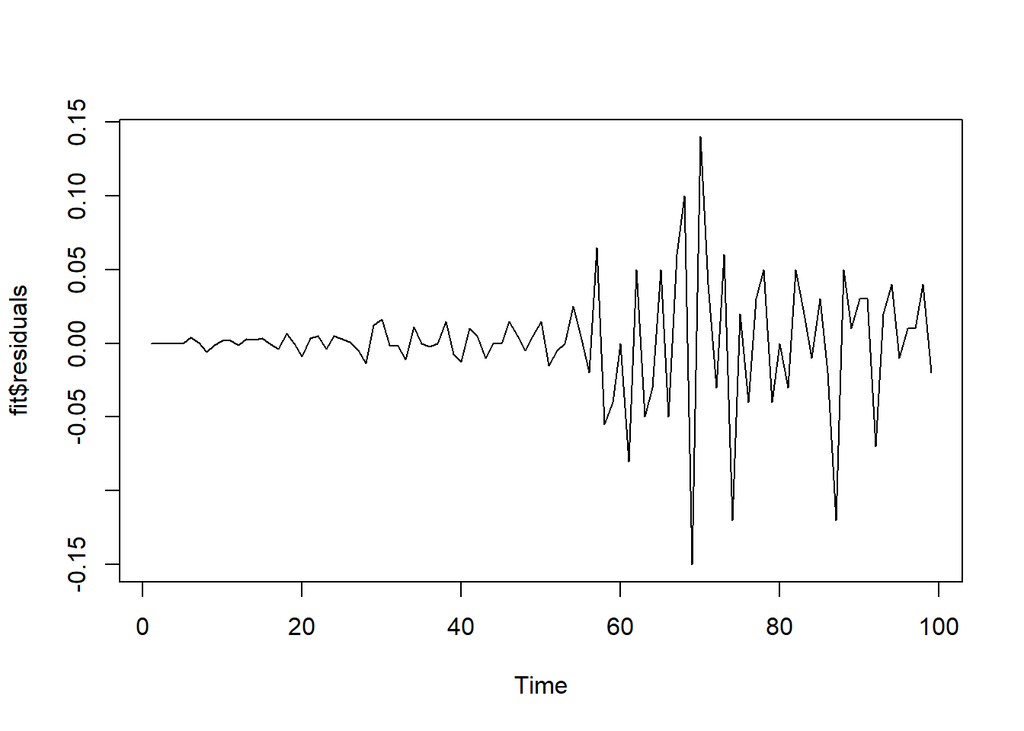

```r
ts.plot(fit$residuals)
```

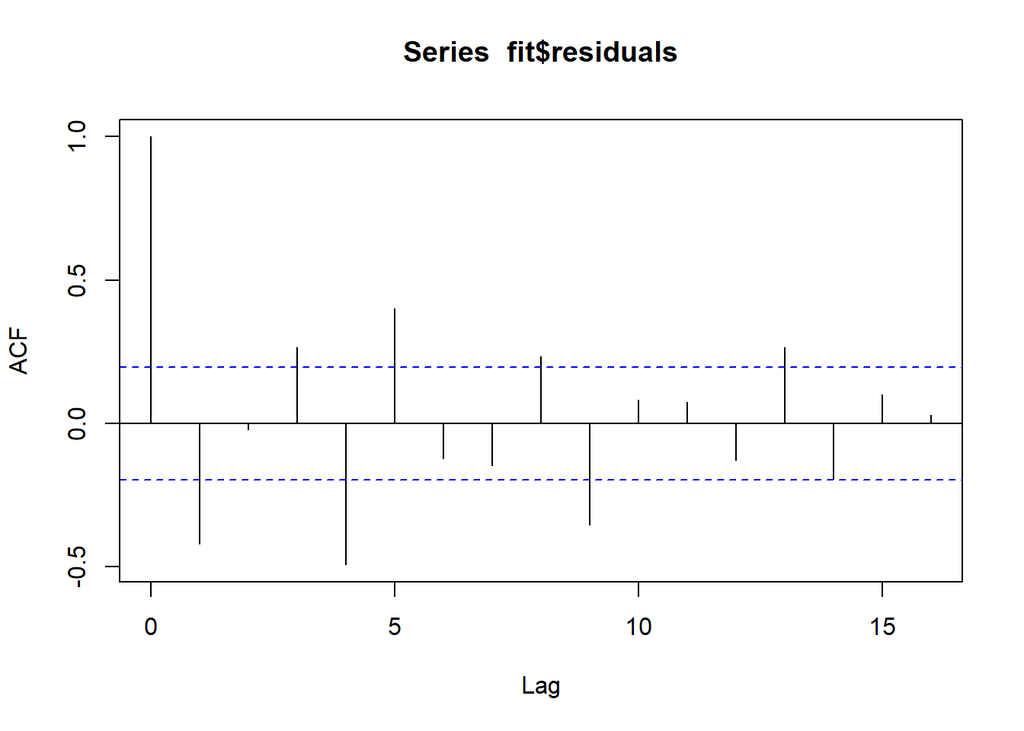

```r
acf(fit$residuals,nlags)
```

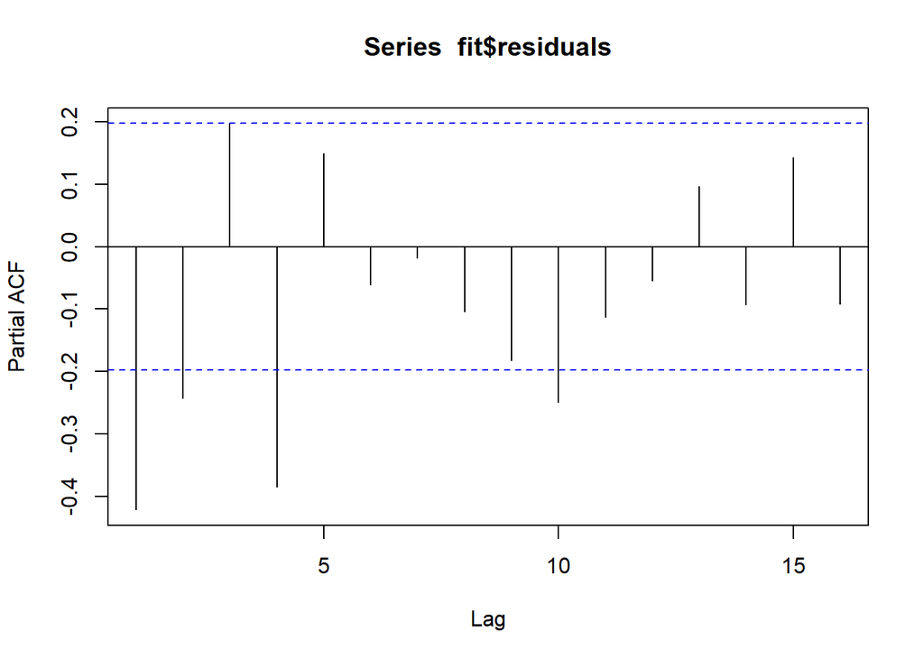

```r
pacf(fit$residuals,nlags)
```

## Seasonal Arima Model

```r
fit1<-arima(y.train,order=c(0,1,0),seasonal=list(order=c(1,1,0),period=s))
fit1
```

```
##
## Call:
## arima(x = y.train, order = c(0, 1, 0), seasonal = list(order = c(1, 1, 0), period = s))
##
## Coefficients:
##          sar1
##       -0.4789
## s.e.   0.0875
##
## sigma^2 estimated as 0.001174:  log likelihood = 183.2,  aic = -362.41
```

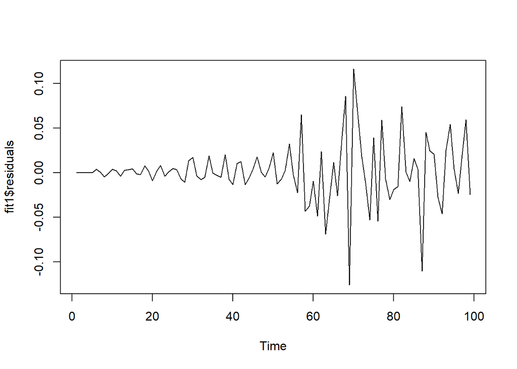

```r
ts.plot(fit1$residuals)
```

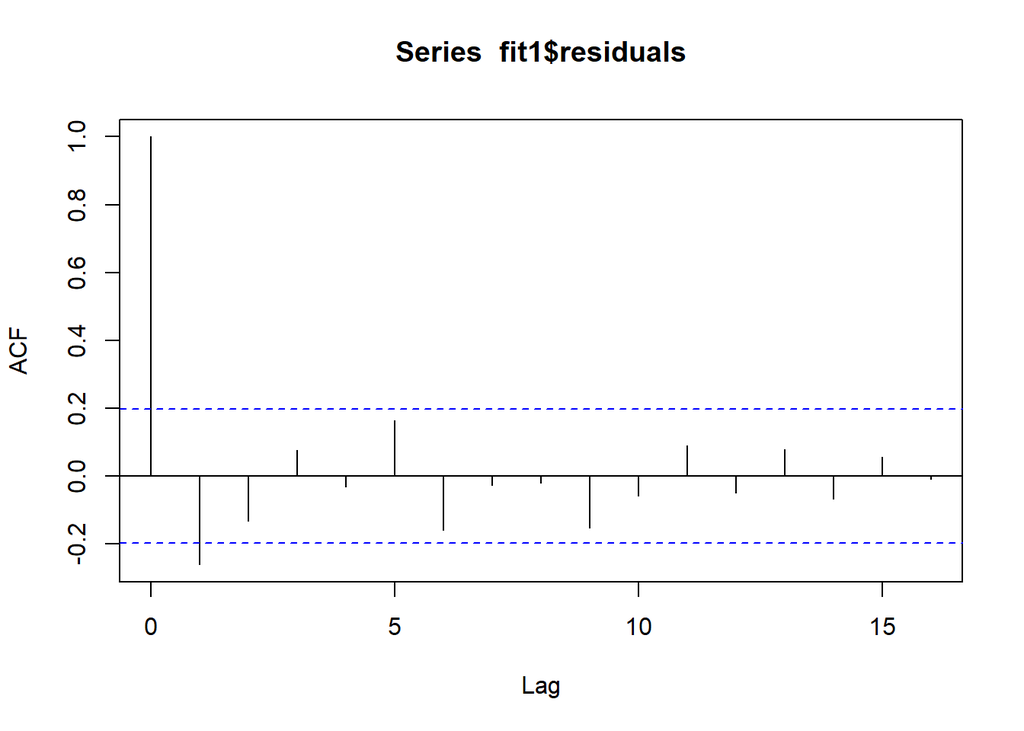

```r
acf(fit1$residuals,nlags)
```

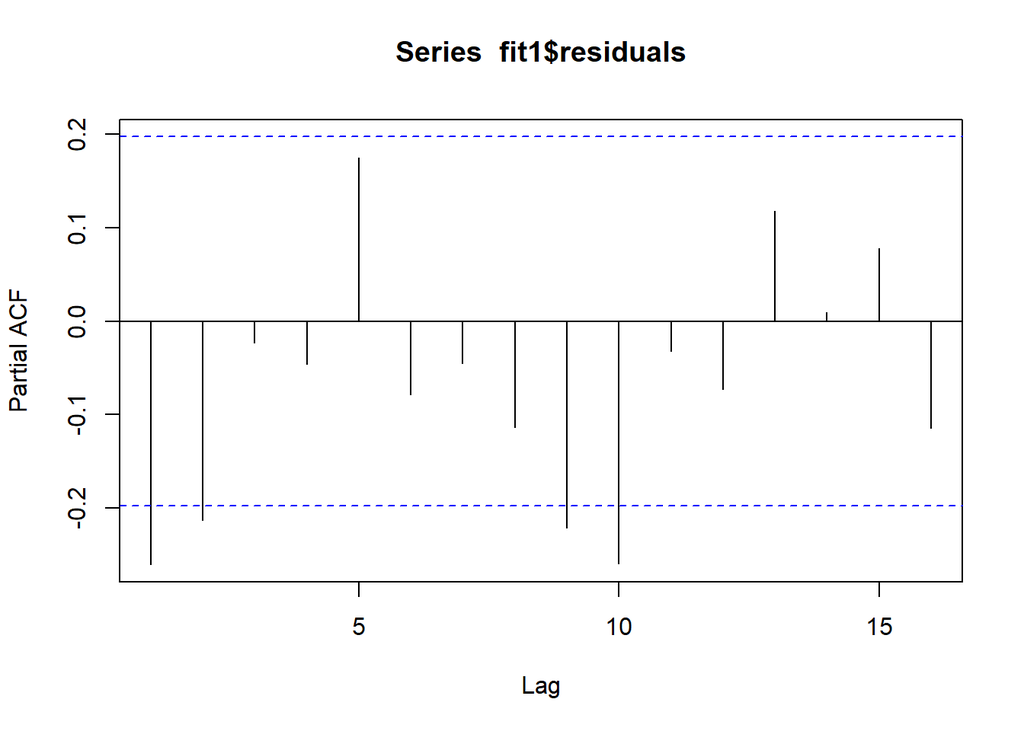

```r
pacf(fit1$residuals,nlags)
```

### Interpretation

From the ACF and the PACF we can notice that this change has been advantageous, there are no more seasonal lags out of limits. Moreover, we can see that the coefficient of the model is statistically different from 0.

## ARIMA Model

```r
fit2<-arima(y.train,order=c(0,1,1),seasonal=list(order=c(1,1,0),period=s))
fit2
```

```
##
## Call:
## arima(x = y.train, order = c(0, 1, 1), seasonal = list(order = c(1, 1, 0), period = s))
##
## Coefficients:
##           ma1     sar1
##       -0.3766  -0.3842
## s.e.   0.1026   0.0972
##
## sigma^2 estimated as 0.001056:  log likelihood = 188.32,  aic = -370.63
```

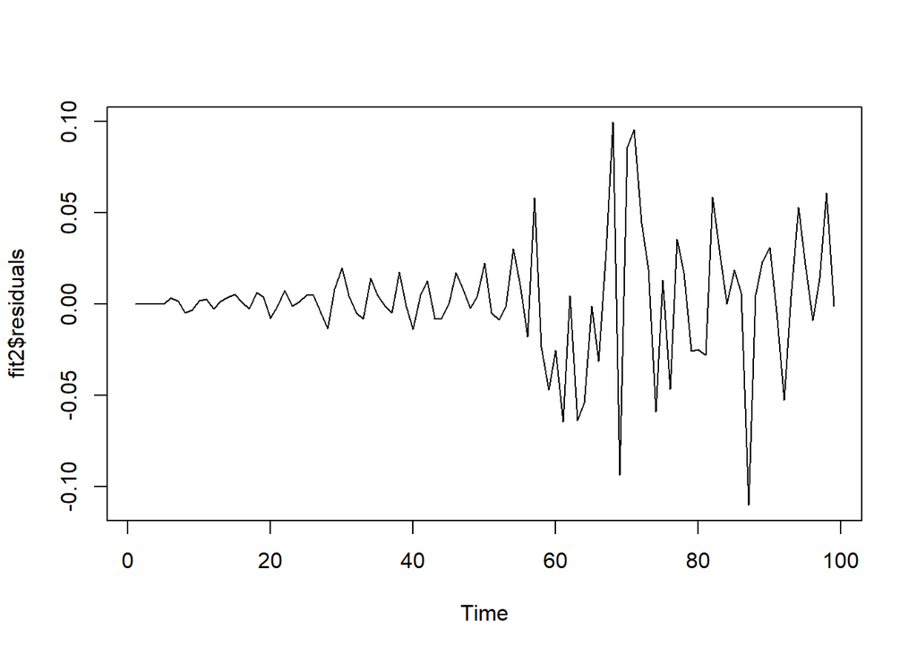

```r
ts.plot(fit2$residuals)
```

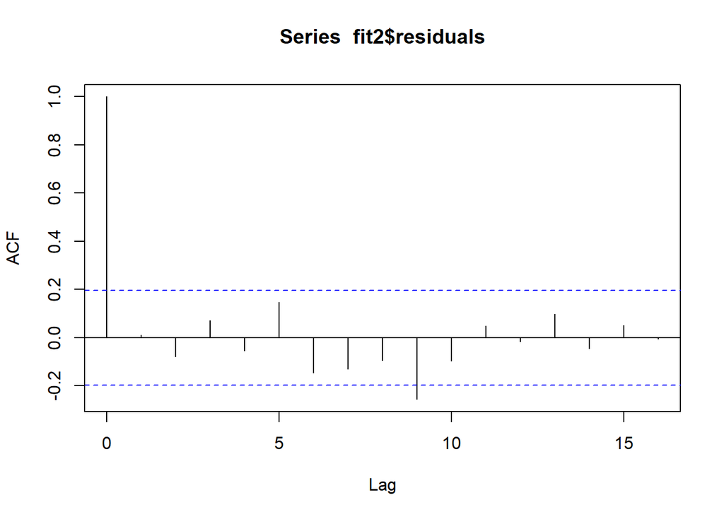

```r
acf(fit2$residuals,nlags)
```

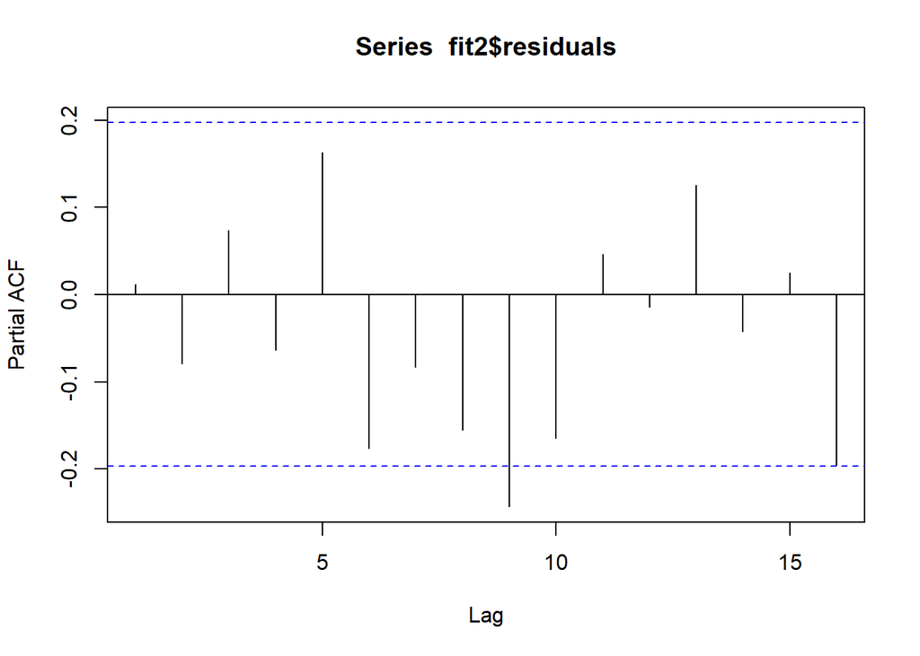

```r
pacf(fit2$residuals,nlags)
```

### Remark:

from the ACF and PACF we see that we still have the 9th lag out of limits but since the data is quarterly, correcting for the 9th lag means that we would need data from more than two years to predict the next quarter value, which may no make sense from the business perspective.

# Log Transformation

We try now to apply the logarithmic transformation in order to remove the non stationarity of the variance

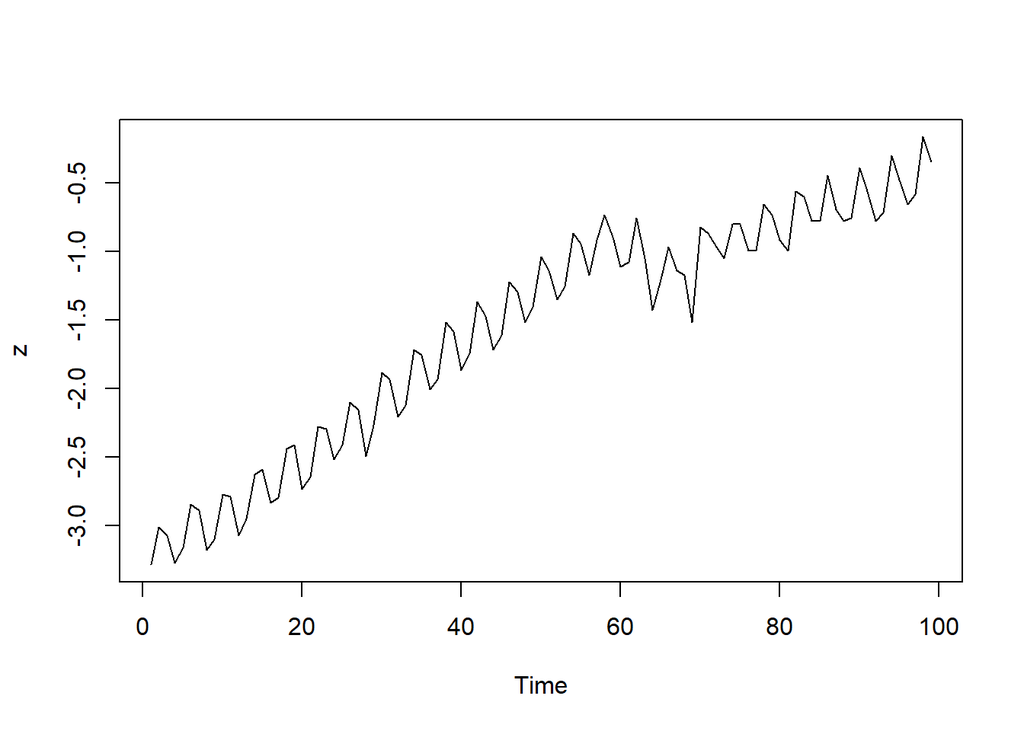

```r
z <- log(y.train)
ts.plot(z)
```

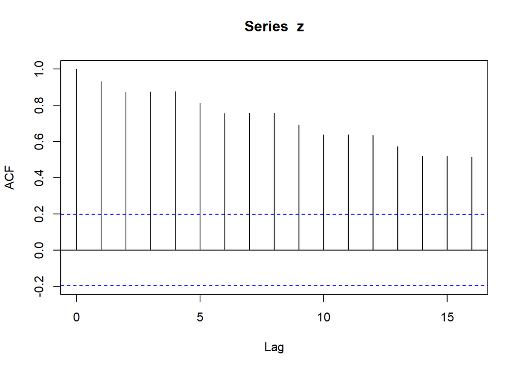

```r
nlags=16

acf(z,nlags)
```

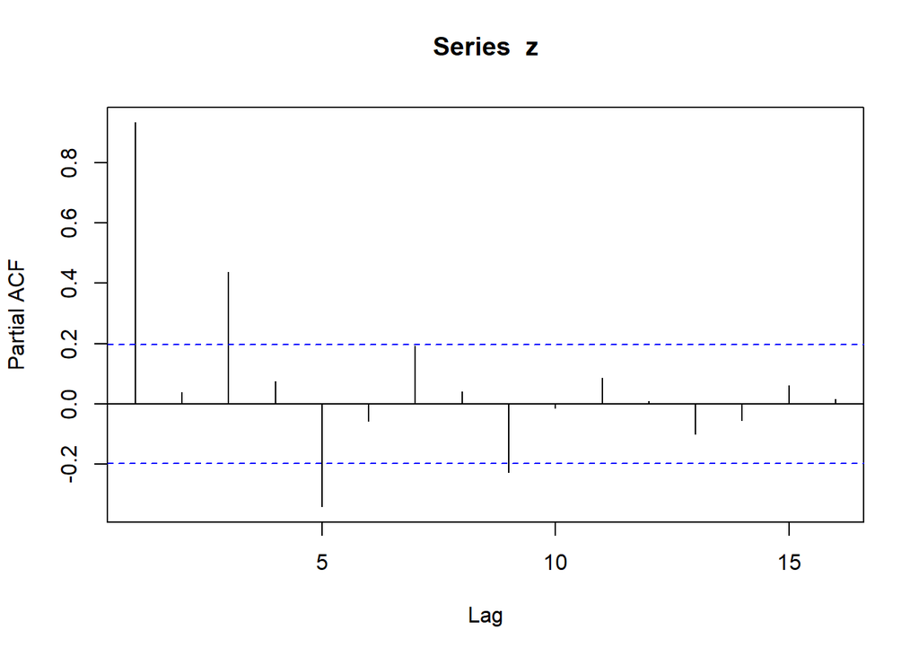

```r
pacf(z,nlags)
```

Applying the Dickey-Fuller test, we can see that one transformation is needed to make the data stationary for both the seasonal differences and the regular differences (the result is 1 in both cases). For this reason, our baseline model will be a SARIMA (0,1,0) x (0,1,0).

```r
s=4      # seasonal parameter
nsdiffs(z,m=s,test=c("ocsb"))  # seasonal differences?
```

```
## [1] 1
```

```r
ndiffs(z, alpha=0.05, test=c("adf")) # regular differences?
```

```
## [1] 1
```

```r
fit3<-arima(z,order=c(0,1,0),seasonal=list(order=c(0,1,0),period=s))
fit3
```

```
##
## Call:
## arima(x = z, order = c(0, 1, 0), seasonal = list(order = c(0, 1, 0), period = s))
##
##
## sigma^2 estimated as 0.01556:  log likelihood = 62.3,  aic = -122.59
```

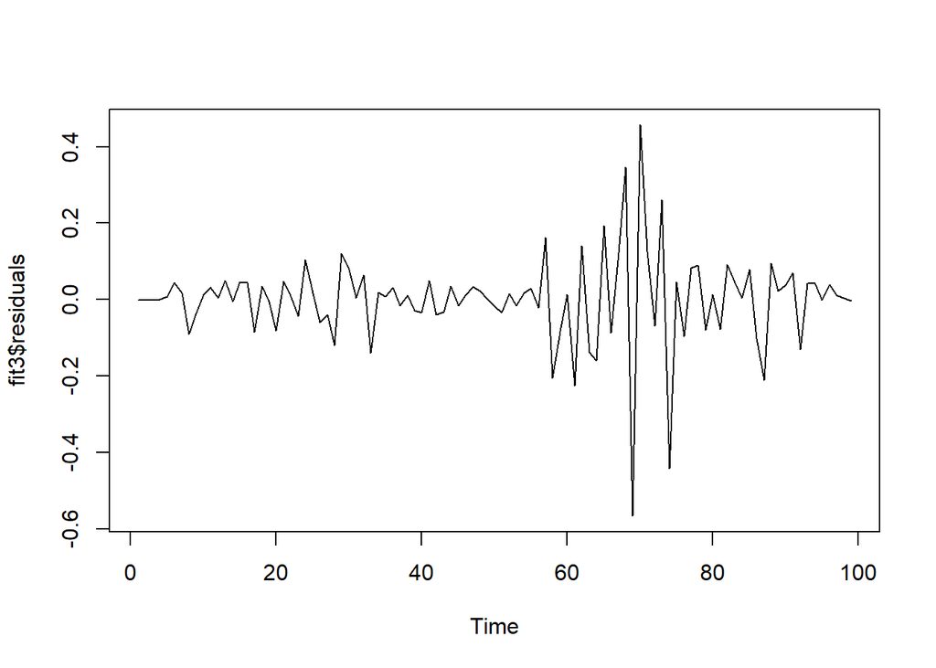

```r
ts.plot(fit3$residuals)
```

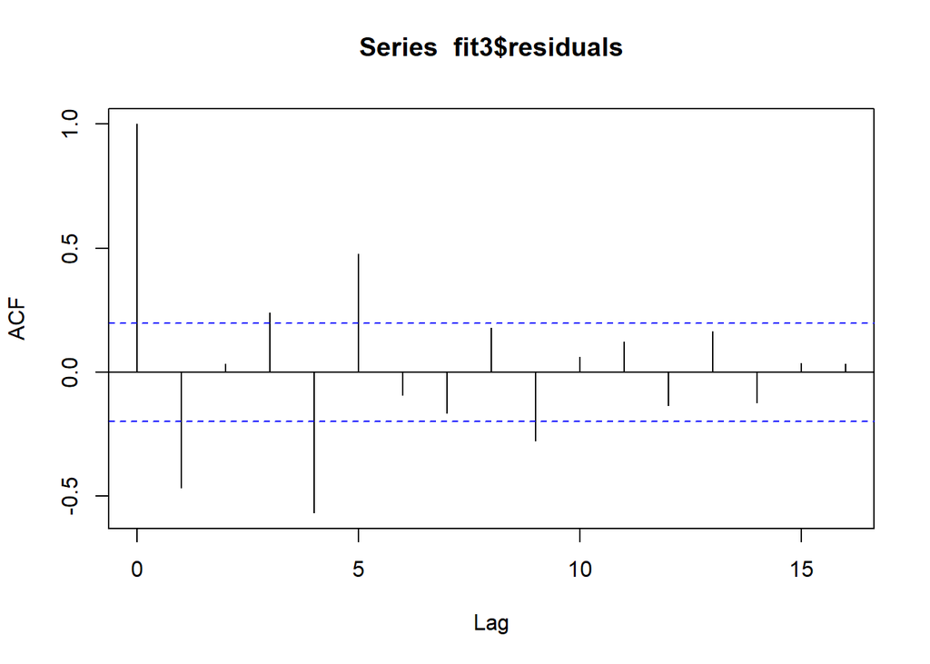

```r
acf(fit3$residuals,nlags)
```

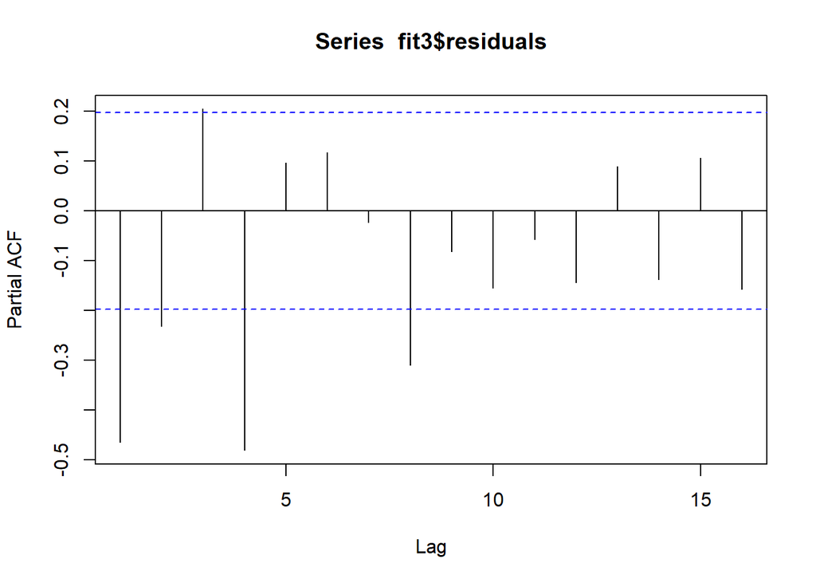

```r
pacf(fit3$residuals,nlags)
```

# Seasonal Arima Model

Looking at the ACF and PACF plotted, we can see that the 4th lag is largely out of limits, the breach of the 8th one is smaller while the others (12,16…) are within the limits. For this reason we will apply a SARIMA (0,1,0) x (1,1,0).

```r
fit4<-arima(z,order=c(0,1,0),seasonal=list(order=c(1,1,0),period=s))
fit4
```

```
##
## Call:
## arima(x = z, order = c(0, 1, 0), seasonal = list(order = c(1, 1, 0), period = s))
##
## Coefficients:
##          sar1
##       -0.5487
## s.e.   0.0822
##
## sigma^2 estimated as 0.01053:  log likelihood = 79.92,  aic = -155.83
```

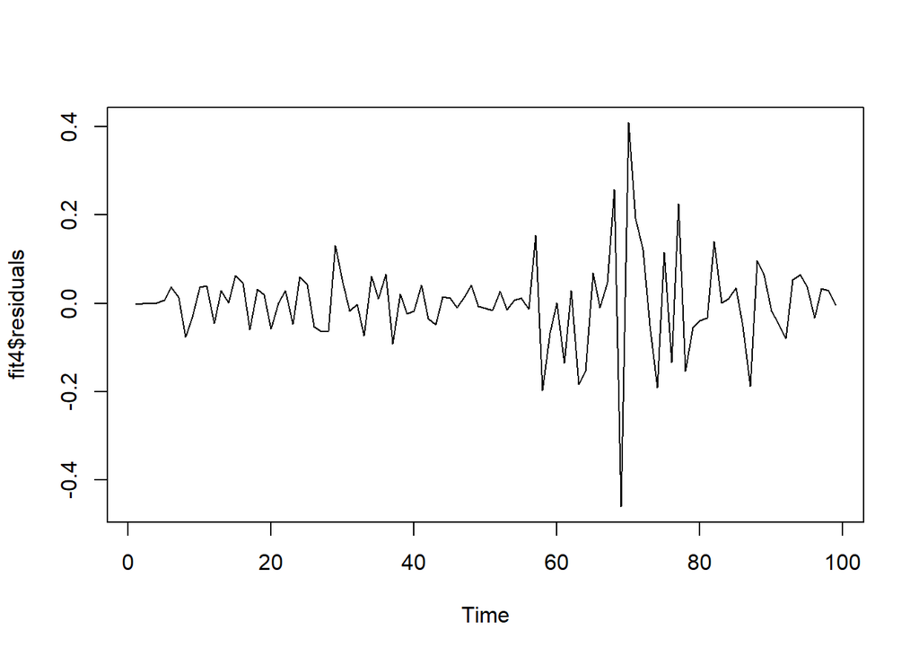

```r
ts.plot(fit4$residuals)
```

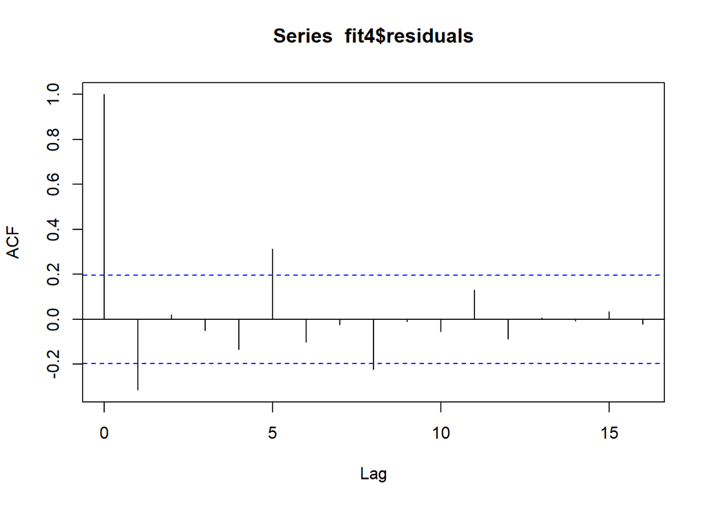

```r
acf(fit4$residuals,nlags)
```

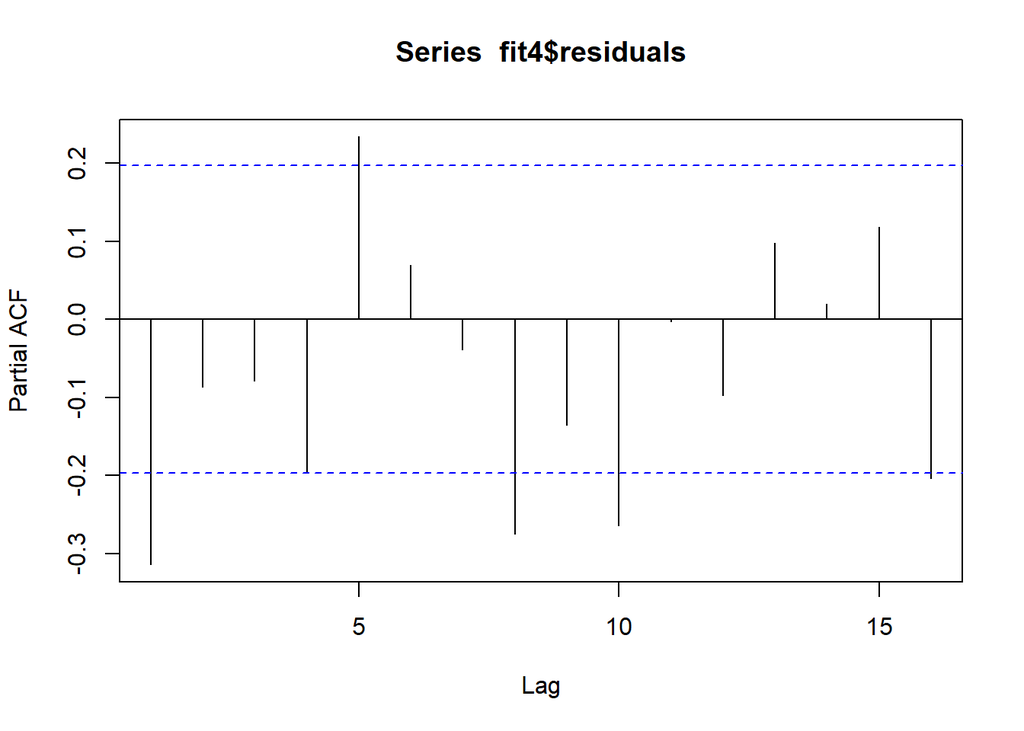

```r
pacf(fit4$residuals,nlags)
```

### Interpretation

From the ACF and the PACF we can notice that this change has been advantageous. Moreover, we can see that the coefficient of the model is statistically different from 0.

## Arima Model

```r
fit5<-arima(z,order=c(8,1,0),seasonal=list(order=c(1,1,0),period=s))
fit5
```

```
##
## Call:
## arima(x = z, order = c(8, 1, 0), seasonal = list(order = c(1, 1, 0), period = s))
##
## Coefficients:
##           ar1      ar2     ar3      ar4     ar5     ar6      ar7      ar8
##       -0.3927  -0.0728  0.0025  -0.4807  0.1413  0.0742  -0.1438  -0.2801
## s.e.   0.0979   0.1055  0.1052   0.1960  0.1160  0.1039   0.1039   0.1097
##          sar1
##       -0.0724
## s.e.   0.2150
##
## sigma^2 estimated as 0.007434:  log likelihood = 95.82,  aic = -171.64
```

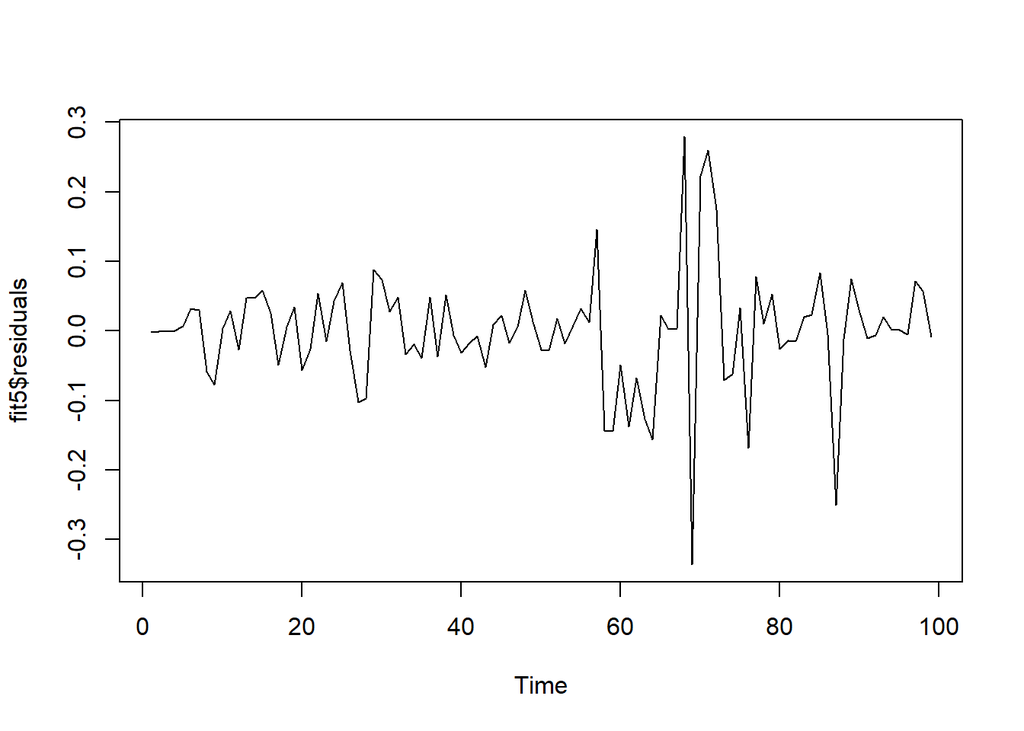

```r
ts.plot(fit5$residuals)
```

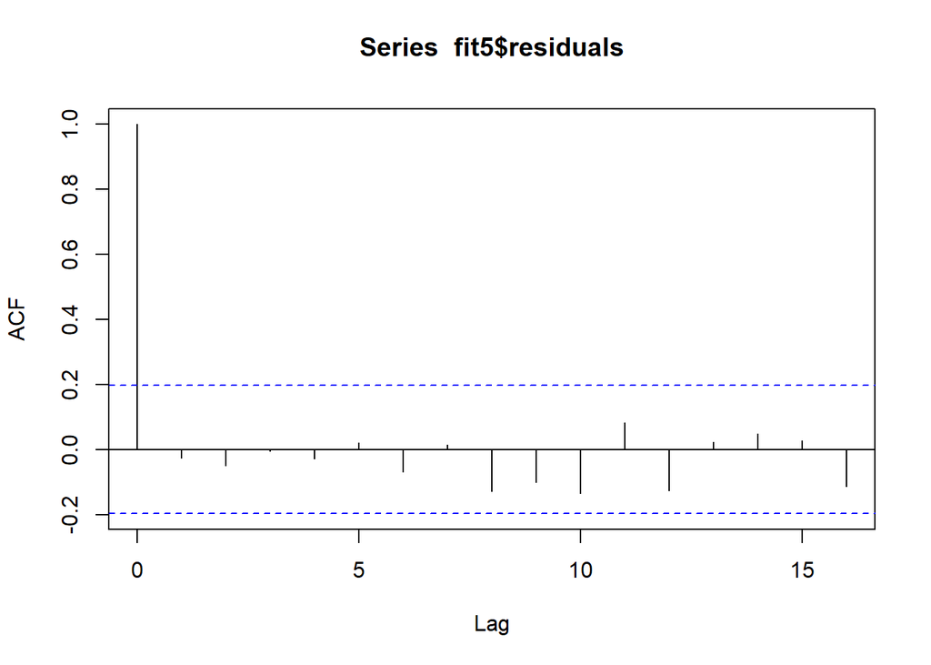

```r
acf(fit5$residuals,nlags)
```

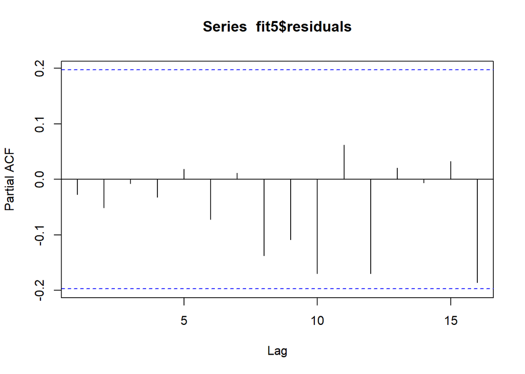

```r
pacf(fit5$residuals,nlags)
```

### Interpretation

From the ACF and the PACF we would say that this change has been advantageous. However, looking at the coefficients of the model, we see that the sarima coefficient is not significant anymore.

## Remove Seasonality

For this reason, we remove the Seasonal autoregressive portion of the model.

```r
fit6<-arima(z,order=c(8,1,0),seasonal=list(order=c(0,1,0),period=s))
fit6
```

```
##
## Call:
## arima(x = z, order = c(8, 1, 0), seasonal = list(order = c(0, 1, 0), period = s))
##
## Coefficients:
##           ar1      ar2     ar3      ar4     ar5     ar6      ar7      ar8
##       -0.3933  -0.0707  0.0069  -0.5360  0.1234  0.0754  -0.1390  -0.2998
## s.e.   0.0971   0.1048  0.1038   0.1035  0.1024  0.1033   0.1025   0.0953
##
## sigma^2 estimated as 0.007446:  log likelihood = 95.76,  aic = -173.52
```

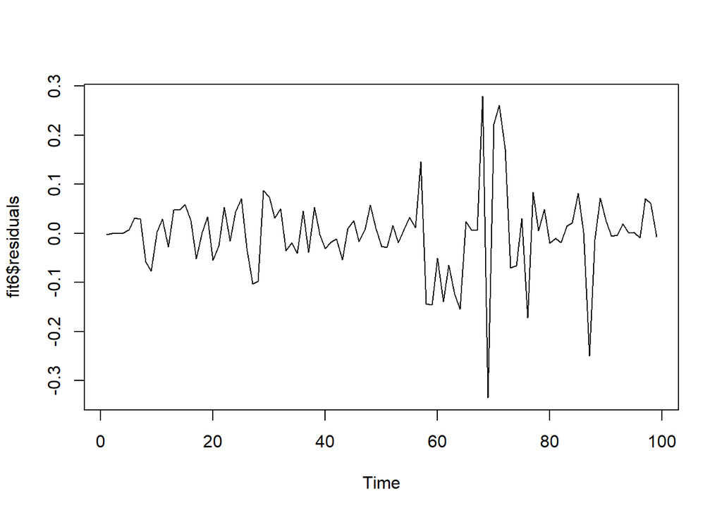

```r
ts.plot(fit6$residuals)
```

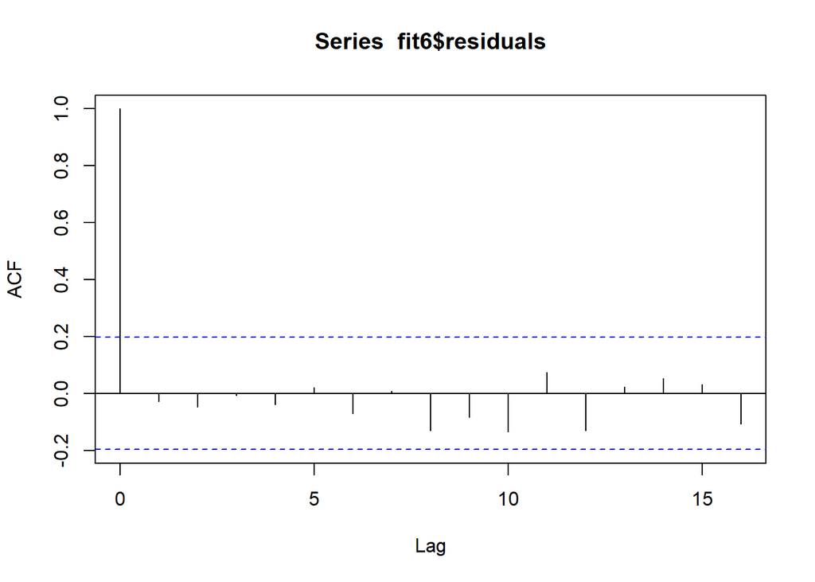

```r
acf(fit6$residuals,nlags)
```

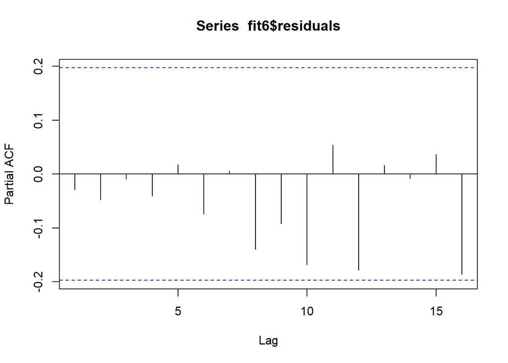

```r
pacf(fit6$residuals,nlags)
```

### Interpretation

From the ACF and PACF above we can see that all the lags of residuals are now within the limits and that the AR(8) coefficient is significant. For this reason, this model will be employed for forecasting.

## WN and Normality testing

```r
#1st model - chosen for forecasting
ndiffs(fit2$residuals, alpha=0.05, test=c("adf")) # regular differences?
```

```
## [1] 0
```

```r
nsdiffs(fit2$residuals, m=s,test=c("ocsb")) # seasonal differences?
```

```
## [1] 0
```

```r
#Test for White Noise
Box.test(fit2$residuals,lag=24)
```

```
##
##  Box-Pierce test
##
## data:  fit2$residuals
## X-squared = 26.732, df = 24, p-value = 0.3171
```

```r
#Test for Normality
shapiro.test(fit2$residuals)
```

```
##
##  Shapiro-Wilk normality test
##
## data:  fit2$residuals
## W = 0.89353, p-value = 7.904e-07
```

```r
#2nd model - chosen for forecasting
ndiffs(fit6$residuals, alpha=0.05, test=c("adf")) # regular differences?
```

```
## [1] 0
```

```r
nsdiffs(fit6$residuals, m=s,test=c("ocsb")) # seasonal differences?
```

```
## [1] 0
```

```r
#Test for White Noise
Box.test(fit6$residuals,lag=24)
```

```
##
##  Box-Pierce test
##
## data:  fit6$residuals
## X-squared = 16.483, df = 24, p-value = 0.8699
```

```r
#Test for Normality
shapiro.test(fit6$residuals)
```

```
##
##  Shapiro-Wilk normality test
##
## data:  fit6$residuals
## W = 0.89804, p-value = 1.271e-06
```

# Comparing the predictions with the actual values of the test set

## 1st model

```r
y.pred<-predict(fit2,n.ahead=8)
y.pred$pred   # point predictions
```

```
## Time Series:
## Start = 100
## End = 107
## Frequency = 1
## [1] 0.6065171 0.6426751 0.9173067 0.7849909 0.6828462 0.7204802 1.0010165
## [8] 0.8657484
```

```r
y.pred$se    # standard errors #RED
```

```
## Time Series:
## Start = 100
## End = 107
## Frequency = 1
## [1] 0.03249740 0.03829548 0.04332443 0.04782749 0.06252408 0.07057540
## [7] 0.07779791 0.08440463
```

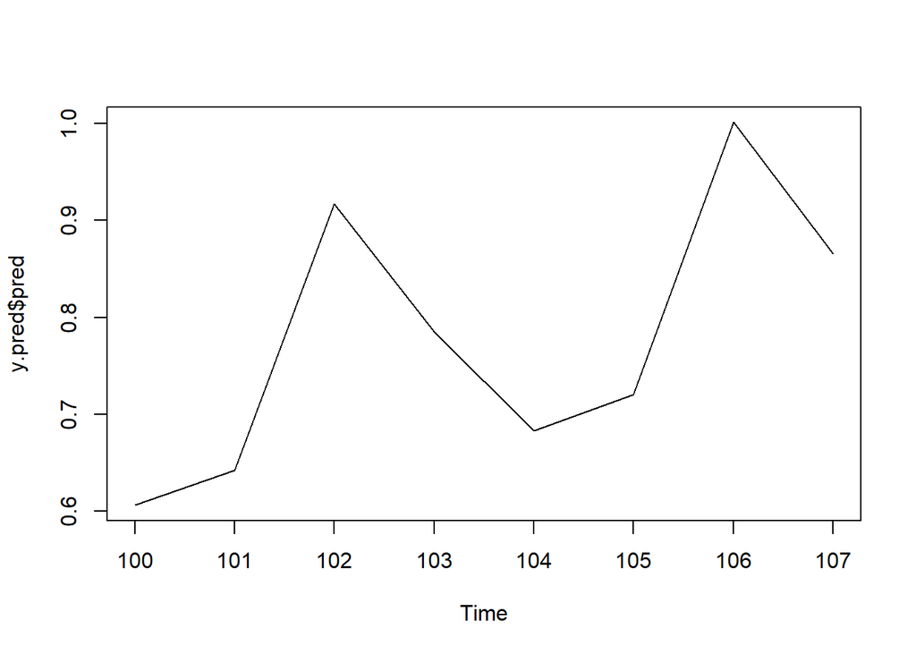

```r
ts.plot(y.pred$pred)  # see how the model captures the seasonality
```

```r
y.test <- data[100:107,2]

y.pred$pred
```

```
## Time Series:
## Start = 100
## End = 107
## Frequency = 1
## [1] 0.6065171 0.6426751 0.9173067 0.7849909 0.6828462 0.7204802 1.0010165
## [8] 0.8657484
```

```r
y.pred$se
```

```
## Time Series:
## Start = 100
## End = 107
## Frequency = 1
## [1] 0.03249740 0.03829548 0.04332443 0.04782749 0.06252408 0.07057540
## [7] 0.07779791 0.08440463
```

```r
y.test
```

```
## [1] 0.58 0.67 1.01 0.83 0.64 0.65 0.92 0.82
```

## 2nd model

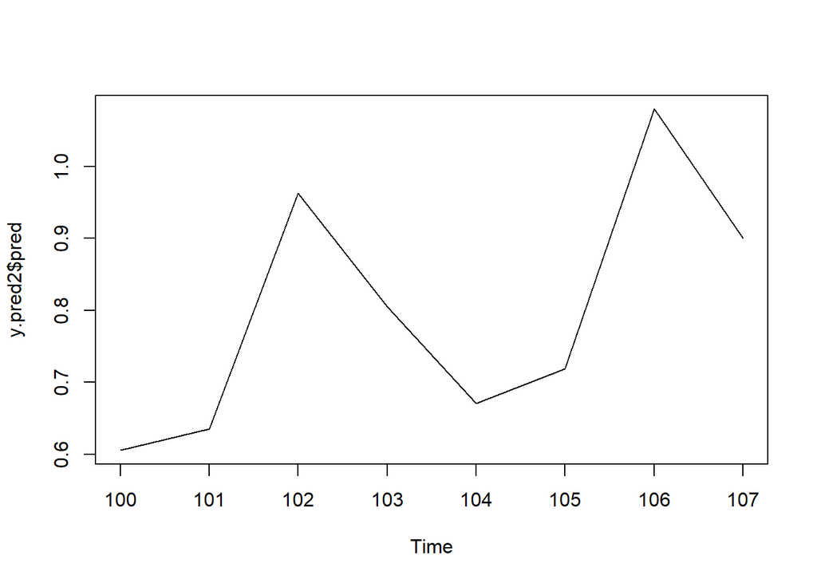

```r
y.pred2<- predict(fit6,n.ahead=8)
y.pred2$pred <- exp(y.pred2$pred)   # undo log
y.pred2$se <- y.pred2$pred * y.pred2$se    # standard errors #RED


ts.plot(y.pred2$pred)  # see how the model captures the seasonality
```

```r
ly.test=log(y.test)

y.pred2$pred
```

```
## Time Series:
## Start = 100
## End = 107
## Frequency = 1
## [1] 0.6056527 0.6355000 0.9624432 0.8044879 0.6710292 0.7187376 1.0794752
## [8] 0.9001593
```

```r
y.pred2$se
```

```
## Time Series:
## Start = 100
## End = 107
## Frequency = 1
## [1] 0.05226107 0.06413927 0.11280889 0.10583817 0.11047414 0.14328724
## [7] 0.24212951 0.21829104
```

```r
exp(ly.test)
```

```
## [1] 0.58 0.67 1.01 0.83 0.64 0.65 0.92 0.82
```

## Compare models

```r
#1
mean((y.pred$pred-y.test)**2)
```

```
## [1] 0.003440942
```

```r
#2
mean((y.pred2$pred)-exp(ly.test)**2)
```

```
## [1] 0.1915356
```

From the results, we would choose model number 1 to be employed for forecasting.